# Linear Models

Assumptions of statistical modelling

Philip Leftwich

University of East Anglia

2026-02-05

# Introduction

## Learning Objectives

# Descriptive Statistics

## Building Statistical Models

A model is a representation of what we think is going on in the real world. It can be a good fit, or a poor fit.

- Descriptive statistics are the simplest models we use to summarise data.
- A well fitted model could be used to make *predictions* about what might happen in the real world.
- If we want our inferences to be **accurate** the model must represent the data collected.

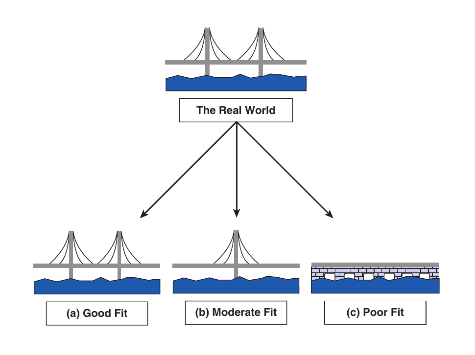

> All statistics are models, some are simpler than others

## Populations

- The total “pool” you are trying to explore/describe
  - “e.g. all the trees in a forest”
- Usually you’re not going to be able to study the entire population, because: time, money, access, resources, support, etc.
- So instead, we can usually only work with a sample

## Sample

- Drawn **randomly** from the population…
- …to collect observations for variable(s) of interest…
- …to try to say something meaningful about the population.
- *A sample can misrepresent the population if it is biased.*

## Data Spread

If data is symmetrically distributed, the **mean and median** will be close, especially as *n* increases.

This shape is characteristic of a **normal distribution**

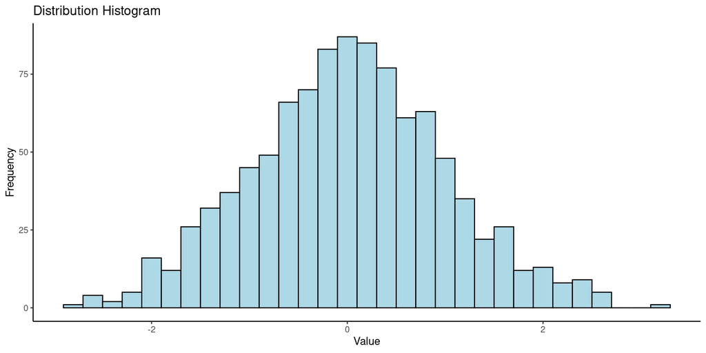

## Variance

Variance measures the average **squared distance** from the mean.

$$s{^2}_{sample} = \frac{\sum(x - \bar{x})^2}{N -1}$$

- Sample variance is a robust measure of data spread, but can be sensitive to outliers.
- A higher variance means more spread.

## Calculating variance

Variance is the average squared distance from the mean; it tells us how spread out the data are

| Value | Distance from mean | Squared distance |
| --- | --- | --- |
| 2 | −2 | 4 |
| 4 | 0 | 0 |
| 6 | +2 | 4 |

Average squared distance:

$$Variance = \frac{4+0+4}{3-1} = 4$$

Why do we square and divide by *n-1*

- Square makes *all* distances positive
- *n-1* stops us underestimating spread when we use a sample

## N-1?

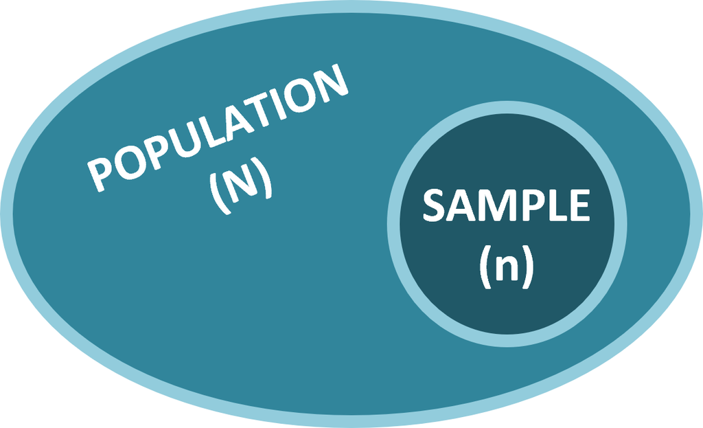

For a *population* the variance $S_p^2$ is exactly the **mean** squared distance of the values from the population mean

$$s{^2}_{pop} = \frac{\sum(x - \bar{x})^2}{N}$$

But this is a *biased* estimate for the population variance

- A biased sample variance will *underestimate* population variance
- n-1 (if you take a large enough sample size, will correct for this)

## Standard Deviation

- Square root of **sample variance**
- A measure of dispersion of the sample
- Smaller SD = more values closer to mean, larger SD = greater data spread from mean
- *variance*:

$$s^2 = \sqrt{\sum(x - \overline x)^2\over n - 1}$$

## Why the Normal Distribution matters

Shape: Symmetrical, bell-shaped curve

- Rule of Thumb: For normally distributed data:

  ~68% within 1 SD

  ~95% within 2 SDs

  ~99.7% within 3 SDs

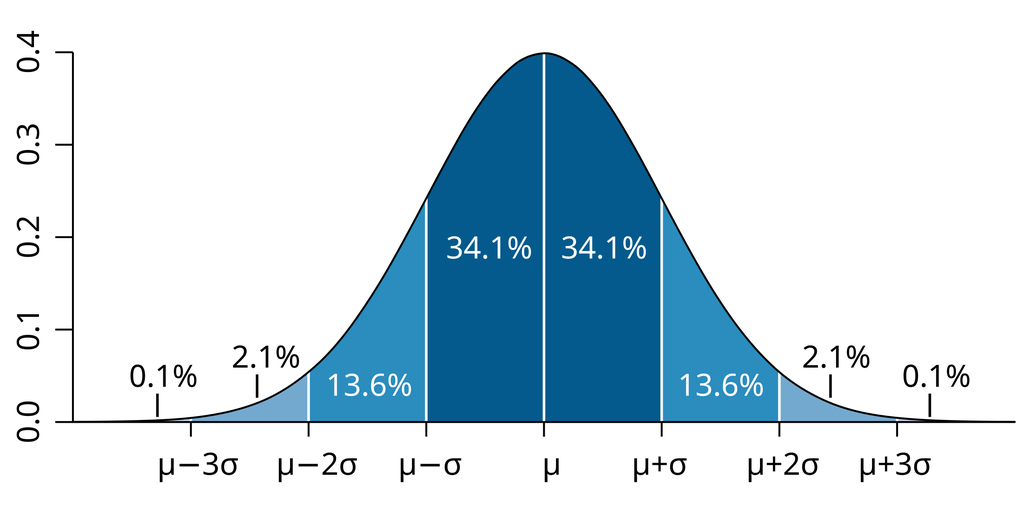

## Visualising a Distribution

**Histograms** show shape

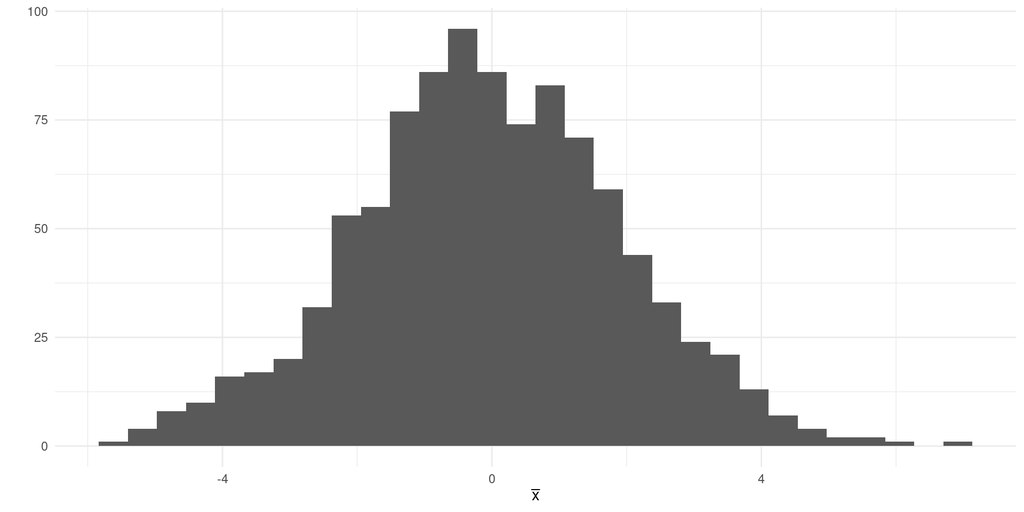

**Quantile-Quantile plots** plots against normality

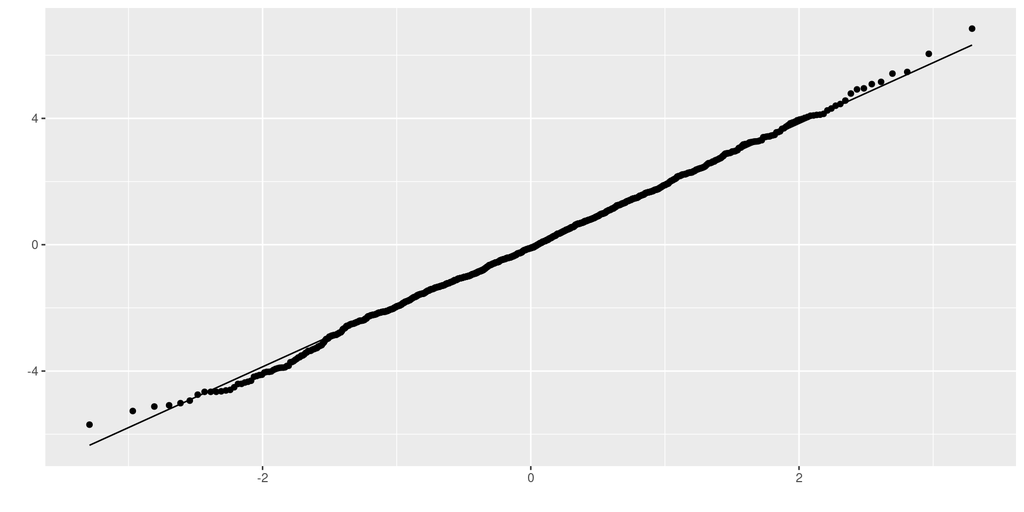

# Inferential Statistics

## Inferential vs Descriptive

### Descriptive

- Summarises the data in a meaningful way
- Measures of central tendency & measures of variability

### Inferential

- Analyses a sample of data to infer about a larger population
- Includes hypothesis testing and building confidence intervals

## Standard deviation predicts data

Standard deviation describes how spread out individual observations are

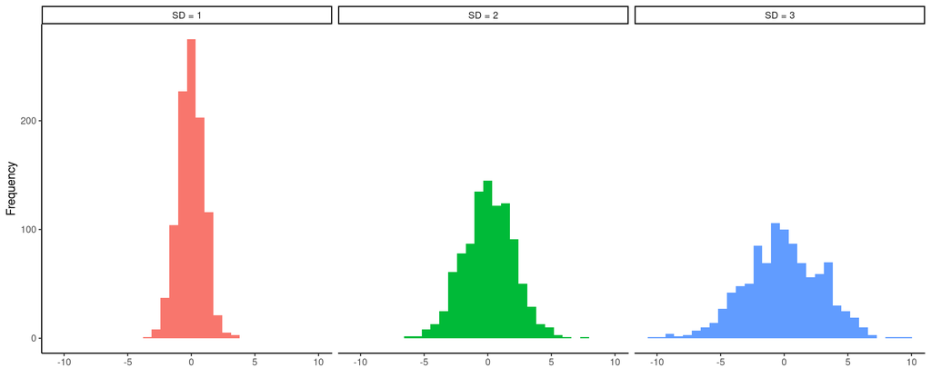

## Introduction to Standard Error

Standard error describes **uncertainty in the mean**, not spread of data

$$SE = {s\over \sqrt n}$$

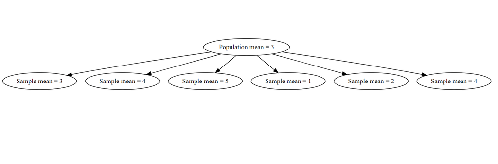

## Standard Error

### Standard deviation vs. standard error:

- Standard deviation measures variability **within** a sample

$s = \sqrt{\sum(x - \overline x)^2\over n - 1}$

- Standard error is how much the sample mean (from a given sample) is likely to vary from the true population mean.

$SE(\overline{X}) = \frac{s}{\sqrt(N)}$

## Standard Error

- Standard Error of the Mean ($\overline{X}$) is the **Standard Deviation of the Sampling Distribution of the Mean.
- If you took many samples from the same population, each sample would give a different mean.

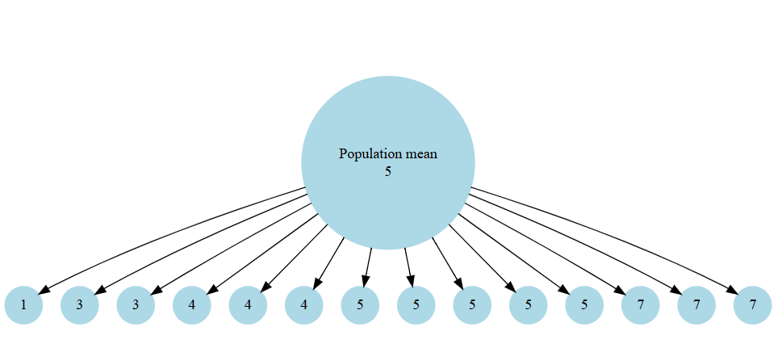

## Confidence Intervals Explained

Can be constructed by YOU:

Do you want to know the range within which you will capture the mean…

The Confidence level (C) is the inverse of the significance level.

$$\alpha = 1 - C$$

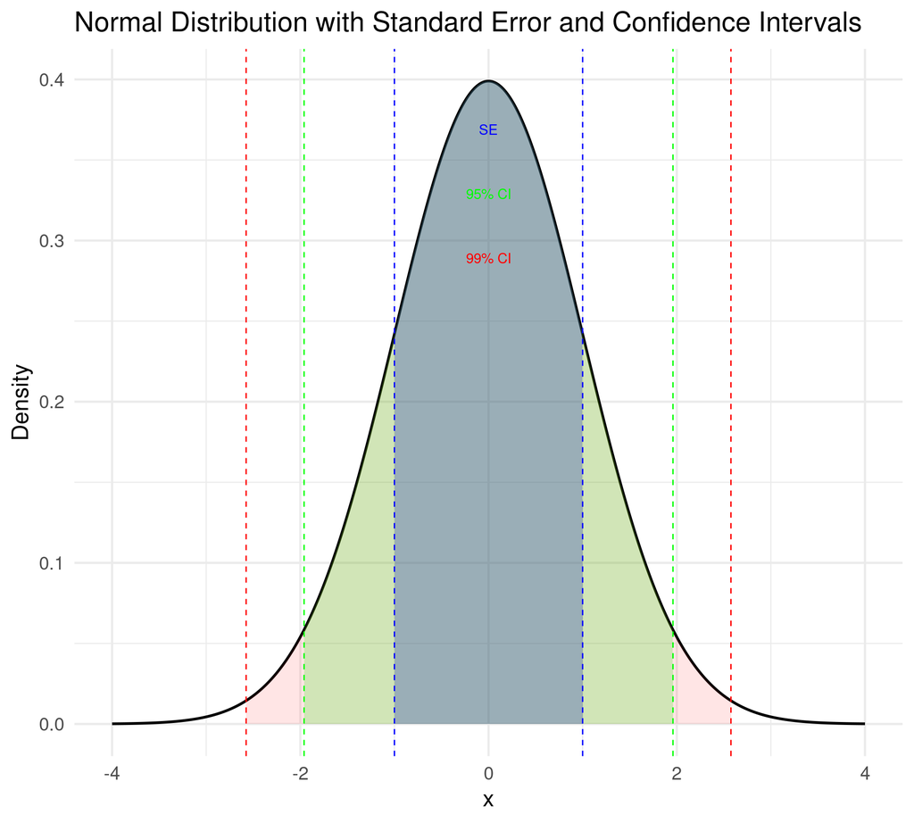

## 95% Confidence interval

“In 95% of experiments we would capture the true mean with our confidence interval range”

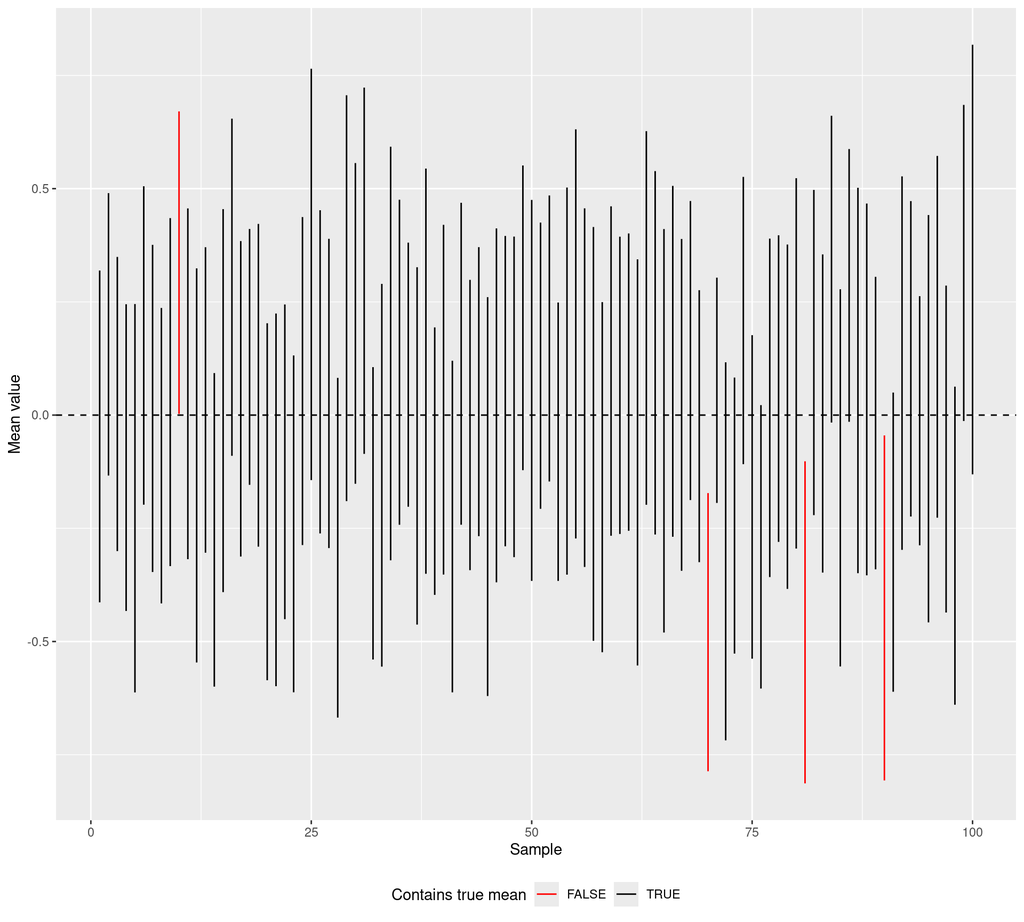

## The T Distribution

- The t-distribution is a correction for small sample size and unknown population variance with an *approximately* normally distributed population

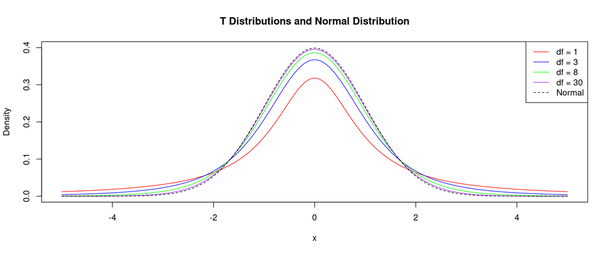

## t vs normal distribution

the t-distribution is closely related to a normal distribution, but influenced by sample size *n* and has **fatter tails**

Calculate Confidence intervals based on *t-distribution*

${95\%~CI} = {\overline x \pm t*SE}$

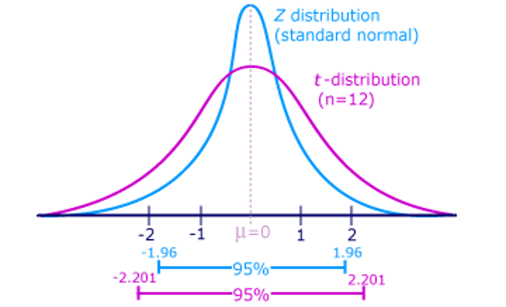

*Calculating t based on sample size WILL affect confidence intervals*

# Linear Models

## Linear models for regression analysis

Difference tests: t-test, ANOVA, ANCOVA

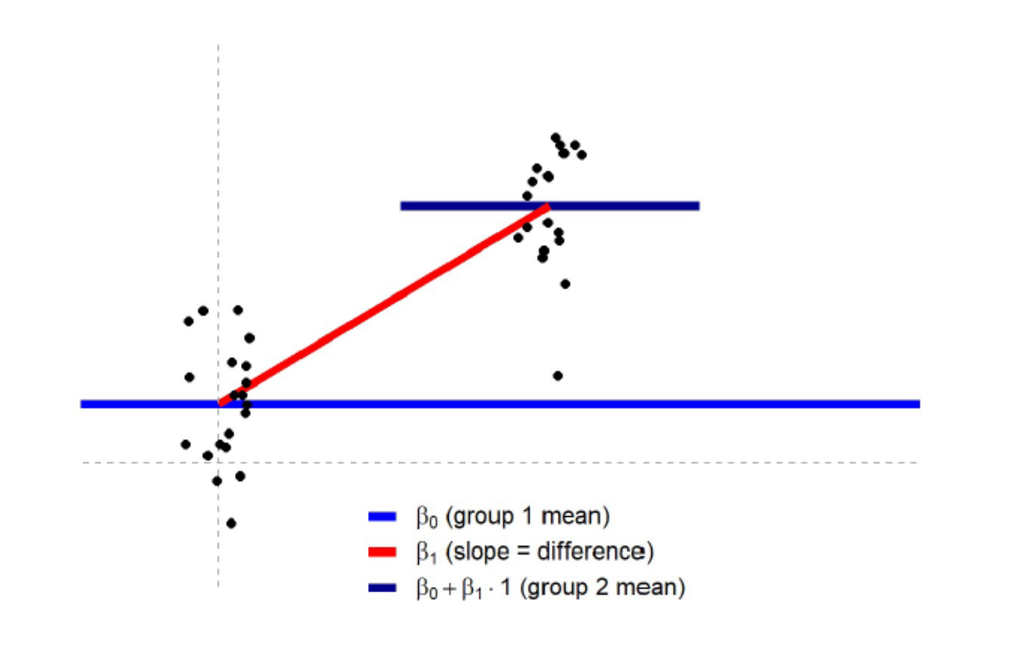

Association tests: Regressions

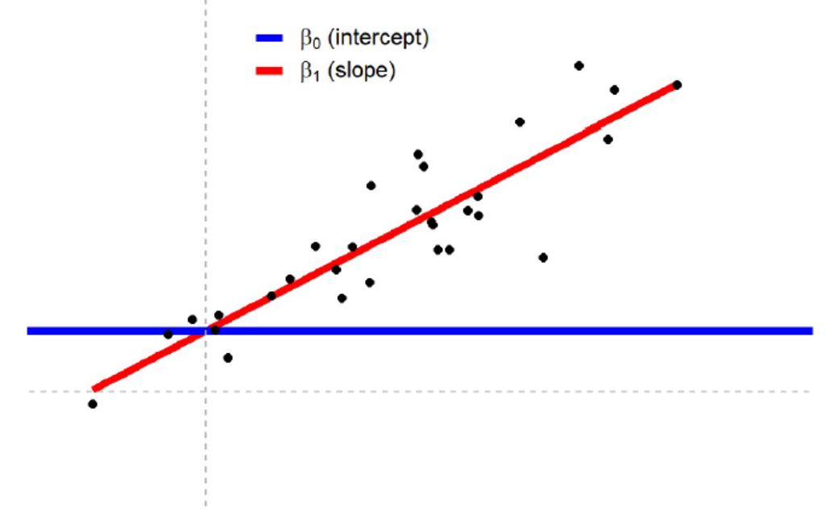

## Straight line equation

$$\LARGE{y = a + bx}$$

### Where:

$y$ is the predicted value of the response variable

$a$ is the intercept (value of y when x = 0)

$b$ is the slope of the regression line

$x$ is the value of the explanatory variable

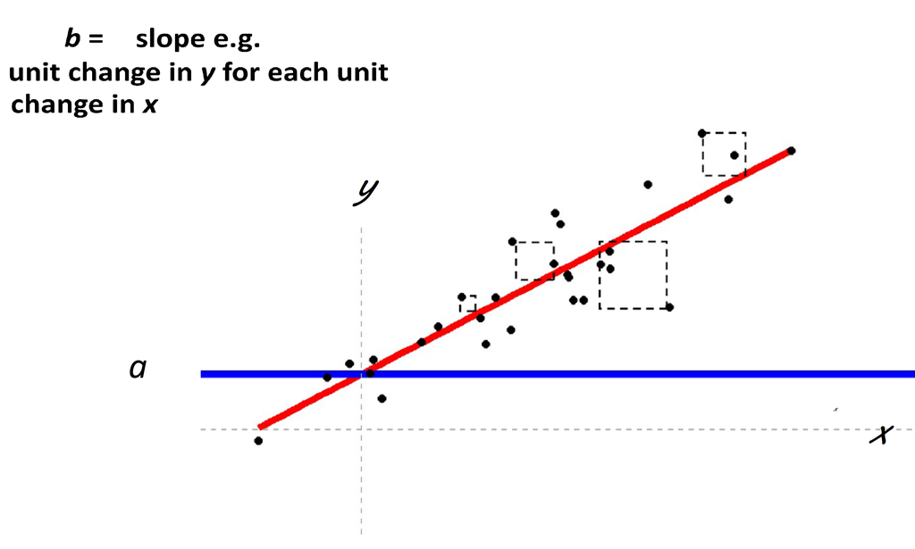

## Line of best fit

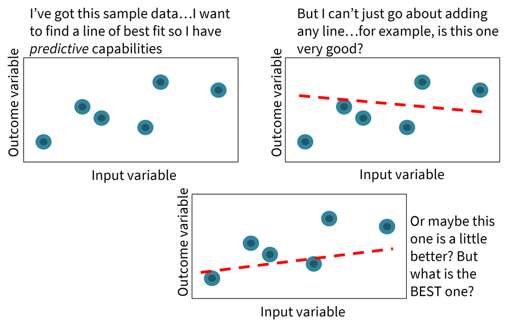

## Ordinary Least Squares

The line of best fit minimises the sum of the **squared distance** that *each* sample point is from the value predicted by the model

This is called the method of

### Ordinary Least Squares

## Residuals

The difference between the ACTUAL value of the observation $y_i$ and the value that the model predicts $\hat{y_i}$ at that $x$ value are the residuals (residual error).

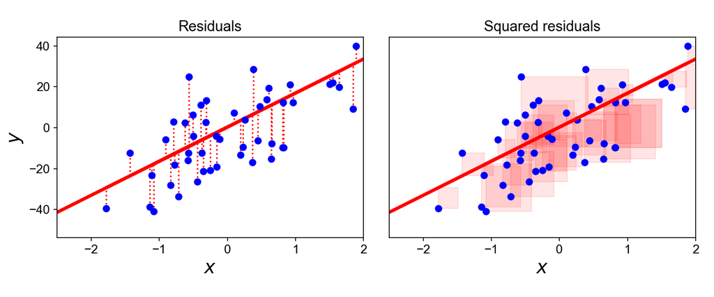

The regression model fitted by **O**rdinary **L**east **S**quares (OLS) will produce the equation for the line that **MINIMIZES** the sum of squares of the residuals

## Sum of Squares Errors

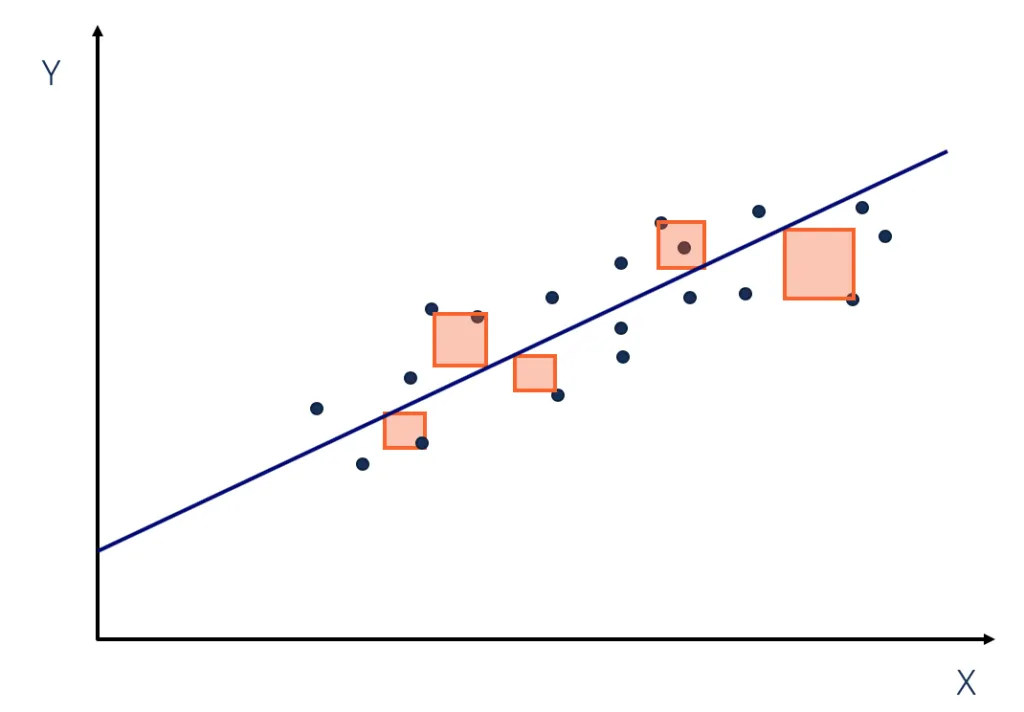

This produces the line with the *smallest* total area size for the squares.

$$SSE = \underset{i=1}{n \atop{\sum}}(y_i - \hat{y_i})^2$$

SUM OF RESIDUAL ERROR = $(2)+(-1)+(4)+(-3)+(-2)=0$

SUM OF SQUARES OF RESIDUAL ERROR = $(2^2)+(-1^2)+(4^2)+(-3^2)+(-2^2)=34$

## Sums of Squares

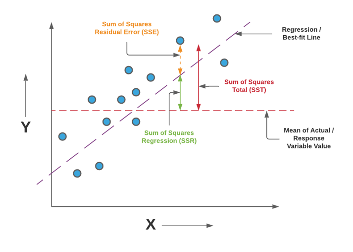

**SST** The squared differences between the observed dependent variable $y_i$ and its overall mean $\overline{y}$.

**SSR** The sum of the differences between the predicted value $\hat{y_i}$ of the dependent variable and its overall mean $\overline{y}$.

**SSE** The error is the difference between the observed dependent value $y_i$ and the predicted value $\hat{y_i}$.

## Linear model equation

$$\LARGE{y_i = a + bx+\epsilon}$$

```r
darwin_ls1 <- lm(height ~ type, data = darwin)
summary(darwin_ls1)
```

```
Call:
lm(formula = height ~ type, data = darwin)

Residuals:
    Min      1Q  Median      3Q     Max
-8.1917 -1.0729  0.8042  1.9021  3.3083

Coefficients:
            Estimate Std. Error t value Pr(>|t|)
(Intercept)  20.1917     0.7592  26.596   <2e-16 ***
typeSelf     -2.6167     1.0737  -2.437   0.0214 *
---
Signif. codes:  0 '***' 0.001 '**' 0.01 '*' 0.05 '.' 0.1 ' ' 1

Residual standard error: 2.94 on 28 degrees of freedom
Multiple R-squared:  0.175, Adjusted R-squared:  0.1455
F-statistic:  5.94 on 1 and 28 DF,  p-value: 0.02141
```

```r
janka_ls1 <- lm(hardness ~ dens, data = janka)
summary(janka_ls1)
```

```
Call:
lm(formula = hardness ~ dens, data = janka)

Residuals:
    Min      1Q  Median      3Q     Max
-338.40  -96.98  -15.71   92.71  625.06

Coefficients:
             Estimate Std. Error t value Pr(>|t|)
(Intercept) -1160.500    108.580  -10.69 2.07e-12 ***
dens           57.507      2.279   25.24  < 2e-16 ***
---
Signif. codes:  0 '***' 0.001 '**' 0.01 '*' 0.05 '.' 0.1 ' ' 1

Residual standard error: 183.1 on 34 degrees of freedom
Multiple R-squared:  0.9493,    Adjusted R-squared:  0.9478
F-statistic:   637 on 1 and 34 DF,  p-value: < 2.2e-16
```

## Coefficient of determination

$\LARGE{R^2}$ : The proportion of variation in the dependent variable that can be predicted from the independent variable

$$\LARGE{R^2=1-{Sum~of~Squared~Distances~between~y_i~and~\hat{y_i}\over{Sum~of~Squared~Distances~between~y_i~and~\overline{y}}} }$$

$$\LARGE{R^2=1-{SSE\over{SST}}}$$

## Compare these write-ups

- “There was a significant effect (*p* < 0.001).”
- “There is a positive association between wood density and timber hardness (*t*<sub>34</sub> = 25.24, *p* = <0.001).”

## A write-up

**I** fitted a linear model (estimated using OLS) to predict **timber hardness from wood density**. The model explains a statistically significant and substantial proportion of variance (F<sub>1,34</sub>) = 636.98, p < .001, adj. R<sup>2</sup> = 0.95). The model shows that for each unit increase in wood density (kg/m^3) there is an **increase** of 57.51 (lbf) on the Janka wood hardness scale (Beta = 57.51, 95% CI [52.88, 62.14], t<sub>34</sub> = 25.24, p < .001). Model residuals were checked against the assumptions of a standard linear model.

# Assumptions

## Assumptions of the Linear Model

- *Errors* should be normally distributed
- Homoscedasticity of the errors
- Independent observations
- A Linear relationship

## Model fit checks

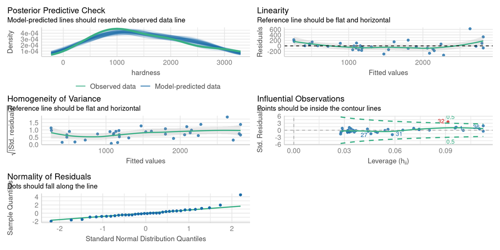

```r
performance::check_model(janka_ls1,
                         detrend = F)
```

## Linearity

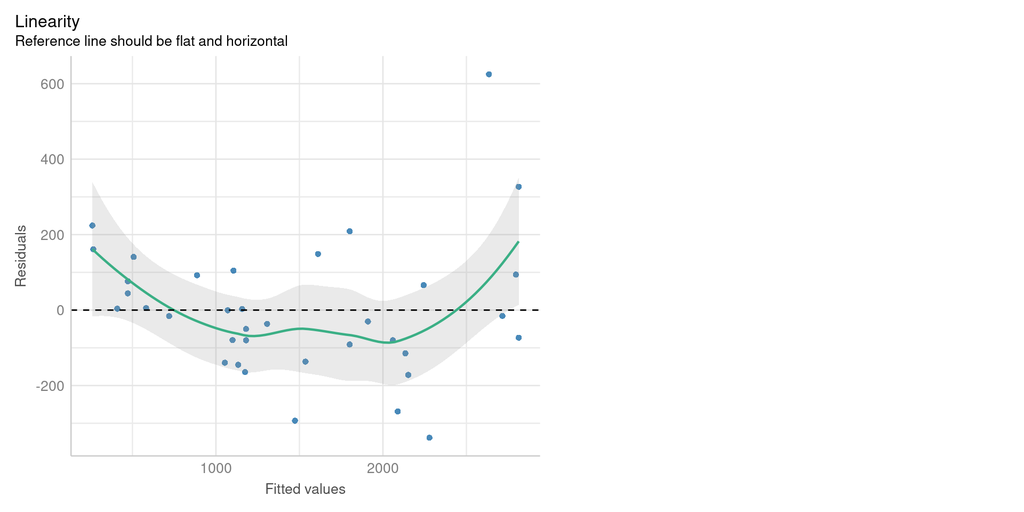

```r
performance::check_model(janka_ls1,
                         check = "linearity")
```

## Normality

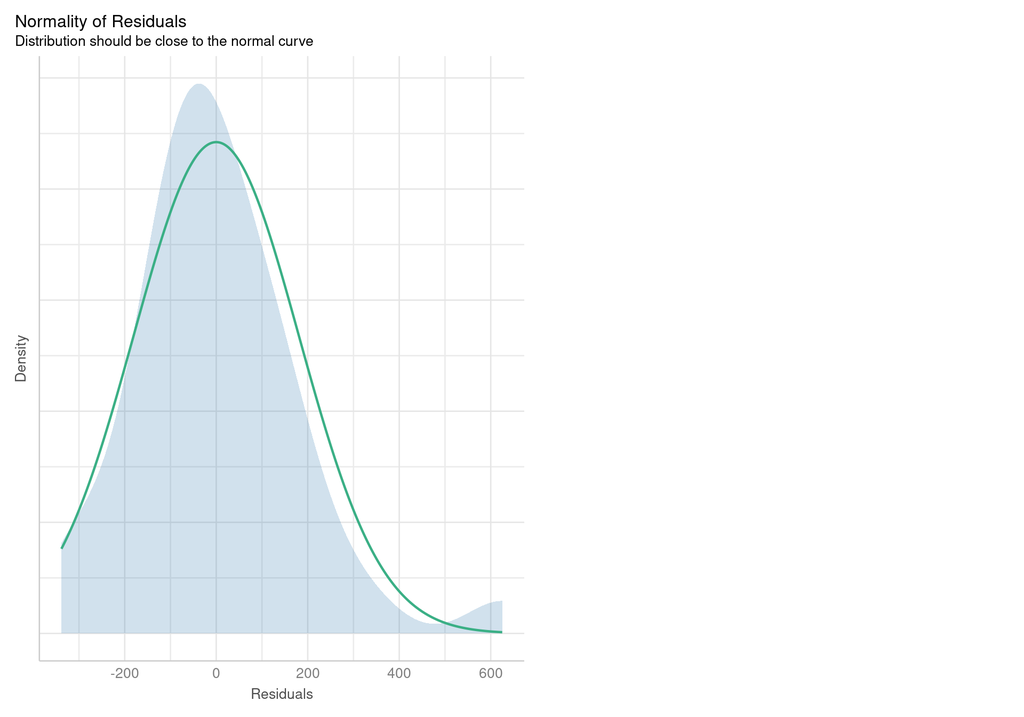

```r
performance::check_model(janka_ls1,
                         check = "normality")
performance::check_normality(janka_ls1)
```

[output not shown]

## Heteroscedasticity

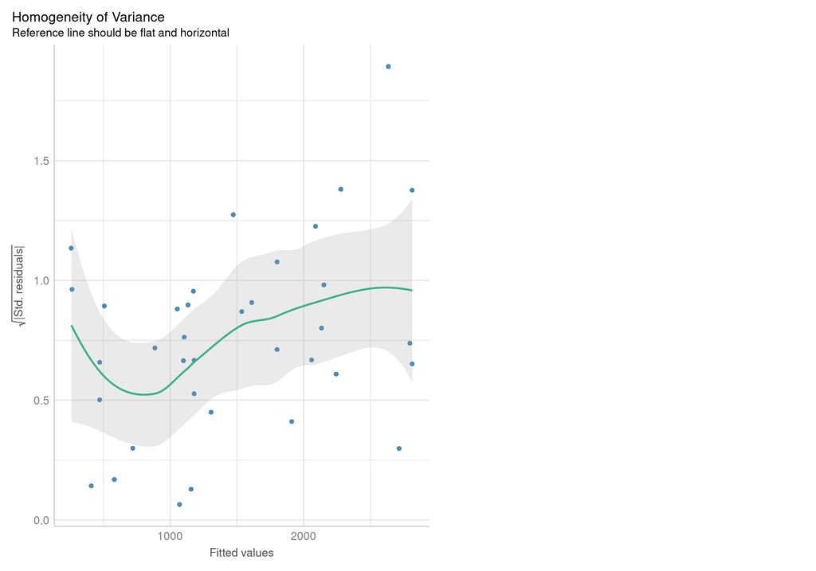

```r
performance::check_model(janka_ls1,
                         check = "homogeneity")
performance::check_heteroscedasticity(janka_ls1)
```

[output not shown]

## Outliers

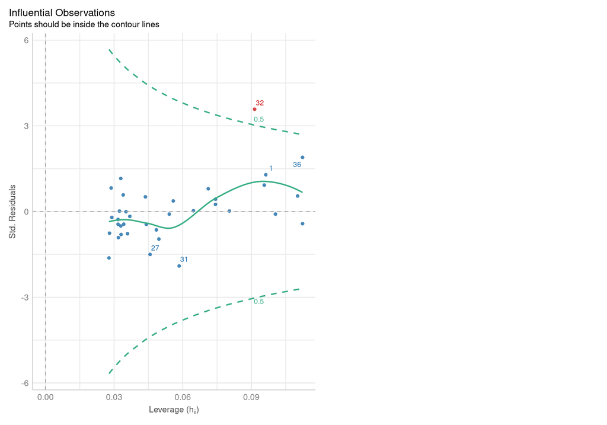

```
OK: No outliers detected.
- Based on the following method and threshold: cook (0.707).
- For variable: (Whole model)
```

```r
performance::check_model(janka_ls1,
                         check = "outliers")
performance::check_outliers(janka_ls1)
```